# 1. Reading in the data

```r
fhs <- read.csv('framingham.csv')
fhs[ 1:10, 1:16 ]
```

```
##    male age education currentSmoker cigsPerDay BPMeds prevalentStroke
## 1     1  39         4             0          0      0               0
## 2     0  46         2             0          0      0               0
## 3     1  48         1             1         20      0               0
## 4     0  61         3             1         30      0               0
## 5     0  46         3             1         23      0               0
## 6     0  43         2             0          0      0               0
## 7     0  63         1             0          0      0               0
## 8     0  45         2             1         20      0               0
## 9     1  52         1             0          0      0               0
## 10    1  43         1             1         30      0               0
##    prevalentHyp diabetes totChol sysBP diaBP   BMI heartRate glucose TenYearCHD
## 1             0        0     195 106.0    70 26.97        80      77          0
## 2             0        0     250 121.0    81 28.73        95      76          0
## 3             0        0     245 127.5    80 25.34        75      70          0
## 4             1        0     225 150.0    95 28.58        65     103          1
## 5             0        0     285 130.0    84 23.10        85      85          0
## 6             1        0     228 180.0   110 30.30        77      99          0
## 7             0        0     205 138.0    71 33.11        60      85          1
## 8             0        0     313 100.0    71 21.68        79      78          0
## 9             1        0     260 141.5    89 26.36        76      79          0
## 10            1        0     225 162.0   107 23.61        93      88          0
```

## dimension of the matrix

```r
dim( fhs )
```

```
## [1] 4240   16
```

There are 4240 subjects.

## variable names

```r
# what are the variable names
names( fhs )
```

```
##  [1] "male"            "age"             "education"       "currentSmoker"
##  [5] "cigsPerDay"      "BPMeds"          "prevalentStroke" "prevalentHyp"
##  [9] "diabetes"        "totChol"         "sysBP"           "diaBP"
## [13] "BMI"             "heartRate"       "glucose"         "TenYearCHD"
```

## attach dataset

```r
# link to dataset
attach( fhs )
```

# 2. Model building

We will start with a forward selection strategy first. If this does not lead to the model with the best goodness of fit, we will consider alternative model along the way.

The variables we have are :

```
  sex, age

  Education

  CurrentSmoker, cigsPerday, heartRate

  PrevalentStroke, prevalentHyp, BPMeds

  diabetes

  glucose, totChol, BMI
```

We will build a simple linear model for the our defined response variable, using only the explanatory variables (or functions of them):

```
  Sex, age, BMI
```

Once we have a model in term of these variables, we will add other interactions

## - response variable

Blood pressure is an health measure of cardiovascular function. In general, high blood pressure indicates poor vascular health, and lower blood pressure indicates otherwise. The ideal blood pressure reading is less than 120/80 mmHg.

General guidelines:

Normal: less than 120/80 mmHg

Elevated: 120/129 / <80 mmHg

Hypertension status 1: 130-139 / 80-90 mmHg

Hypertension status 2: 140 or higher / 90 or higher mmHg

we decide to make our response variable as the difference between of the systolic blood pressure and the diastolic blood pressure.

When blood pressure is taken, systolic and diastolic blood pressures are measured.

```
  1. Systolic pressure (the top number in the blood pressure reading) measures the pressure of the arteries when the heart push the oxygenated blood out into the circulatory system during the contraction phase.

  2. Dystolic pressure (the bottom number in the blood pressure reading) measures the pressure of the arteries in between contraction, when the heart is at the relaxation phase.
```

```r
# define the difference bet. systolic and dystolic pressure
bpd = sysBP - diaBP

# create the log.bpd variable
log.bpd = log(bpd)
```

```r
# is.smoker equals to 1 if the the individual currently smokes, 0 otherwise.
is.smoker <- ifelse( currentSmoker == 1, 1, 0 )
#is.smoker
```

# 2.1 What do we add first?

We will add each of these explanatory variables: age, gender, and BMI to the null (intercept-only) model. Which model do you prefer and why? Address this in our report.

## - add age

Does age has to do with cardiovascular health?

In theory, yes, because age is a risk factor for age-related cardiovascular declines.

```r
age.model <- lm ( log.bpd ~ age )
summary( age.model )
```

```
##
## Call:
## lm(formula = log.bpd ~ age)
##
## Residuals:
##      Min       1Q   Median       3Q      Max
## -1.01065 -0.16238 -0.00306  0.15327  1.01834
##
## Coefficients:
##              Estimate Std. Error t value Pr(>|t|)
## (Intercept) 3.1912082  0.0225468  141.54   <2e-16 ***
## age         0.0135254  0.0004481   30.18   <2e-16 ***
## ---
## Signif. codes:  0 '***' 0.001 '**' 0.01 '*' 0.05 '.' 0.1 ' ' 1
##
## Residual standard error: 0.2501 on 4238 degrees of freedom
## Multiple R-squared:  0.1769, Adjusted R-squared:  0.1767
## F-statistic:   911 on 1 and 4238 DF,  p-value: < 2.2e-16
```

```r
anova( age.model )
```

```
## Analysis of Variance Table
##
## Response: log.bpd
##             Df  Sum Sq Mean Sq F value    Pr(>F)
## age          1  56.993  56.993  911.04 < 2.2e-16 ***
## Residuals 4238 265.122   0.063
## ---
## Signif. codes:  0 '***' 0.001 '**' 0.01 '*' 0.05 '.' 0.1 ' ' 1
```

### plot

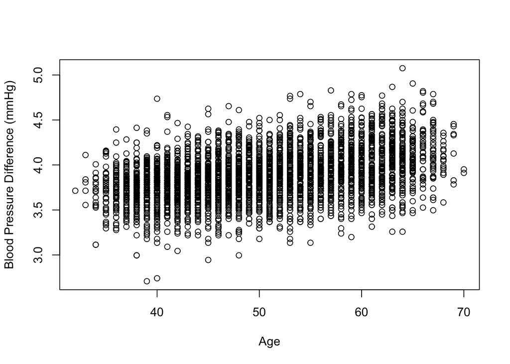

```r
plot( age, log.bpd,
      xlab = "Age", ylab = "Blood Pressure Difference (mmHg)" )
```

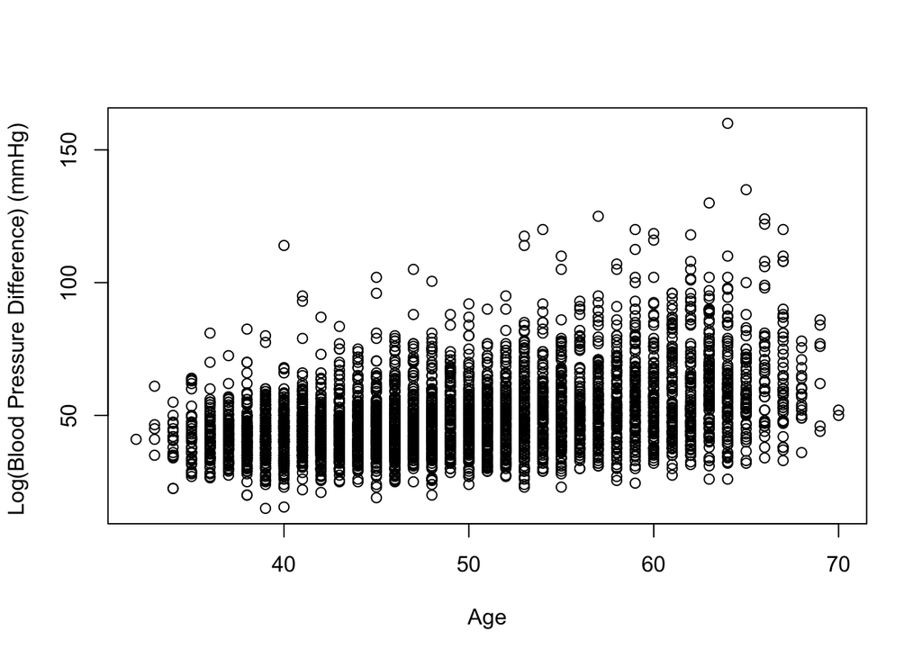

```r
plot( age, bpd,
      xlab = "Age", ylab = "Log(Blood Pressure Difference) (mmHg) " )
```

Address this in the report:

Why do we choose the log transformed response variable vs the non log transformed response variable?

## - add gender

Does gender contribute to heart health?

```r
# is.female equals to 0 if the gender is female, 1 otherwise.
is.female <- ifelse( male == 1, 0, 1 )
#is.female
```

```r
gender.model <- lm( log.bpd ~ is.female )
summary( gender.model )
```

```
##
## Call:
## lm(formula = log.bpd ~ is.female)
##
## Residuals:
##      Min       1Q   Median       3Q      Max
## -1.17545 -0.19462 -0.01523  0.15955  1.19167
##
## Coefficients:
##             Estimate Std. Error t value Pr(>|t|)
## (Intercept) 3.832940   0.006436 595.580  < 2e-16 ***
## is.female   0.050564   0.008519   5.936 3.16e-09 ***
## ---
## Signif. codes:  0 '***' 0.001 '**' 0.01 '*' 0.05 '.' 0.1 ' ' 1
##
## Residual standard error: 0.2746 on 4238 degrees of freedom
## Multiple R-squared:  0.008245,   Adjusted R-squared:  0.008011
## F-statistic: 35.23 on 1 and 4238 DF,  p-value: 3.16e-09
```

```r
anova( gender.model )
```

```
## Analysis of Variance Table
##
## Response: log.bpd
##             Df Sum Sq Mean Sq F value   Pr(>F)
## is.female    1   2.66 2.65584  35.233 3.16e-09 ***
## Residuals 4238 319.46 0.07538
## ---
## Signif. codes:  0 '***' 0.001 '**' 0.01 '*' 0.05 '.' 0.1 ' ' 1
```

## - add bmi

```r
BMI.model <- lm( log.bpd ~ fhs$BMI )
summary(BMI.model)
```

```
##
## Call:
## lm(formula = log.bpd ~ fhs$BMI)
##
## Residuals:
##      Min       1Q   Median       3Q      Max
## -1.16472 -0.18097 -0.01419  0.15927  1.05504
##
## Coefficients:
##             Estimate Std. Error t value Pr(>|t|)
## (Intercept) 3.546993   0.026661  133.04   <2e-16 ***
## fhs$BMI     0.012188   0.001021   11.94   <2e-16 ***
## ---
## Signif. codes:  0 '***' 0.001 '**' 0.01 '*' 0.05 '.' 0.1 ' ' 1
##
## Residual standard error: 0.2705 on 4219 degrees of freedom
##   (19 observations deleted due to missingness)
## Multiple R-squared:  0.03269,    Adjusted R-squared:  0.03246
## F-statistic: 142.6 on 1 and 4219 DF,  p-value: < 2.2e-16
```

```r
anova(BMI.model)
```

```
## Analysis of Variance Table
##
## Response: log.bpd
##             Df  Sum Sq Mean Sq F value    Pr(>F)
## fhs$BMI      1  10.434 10.4343   142.6 < 2.2e-16 ***
## Residuals 4219 308.714  0.0732
## ---
## Signif. codes:  0 '***' 0.001 '**' 0.01 '*' 0.05 '.' 0.1 ' ' 1
```

The p-value is 2e-16.

What does this p-value tell us ?

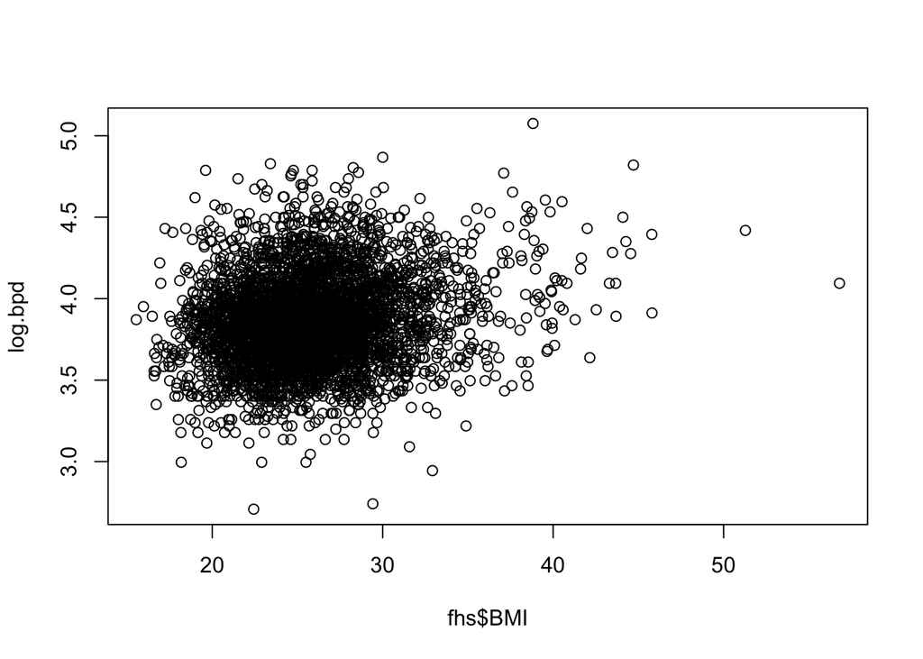

```r
plot(fhs$BMI, log.bpd)
```

# 2.2 producing residual diagnostic plots

We will be looking at many residual diagnostic plots as we try to find a model that reasonably explains the data.

## 1) age

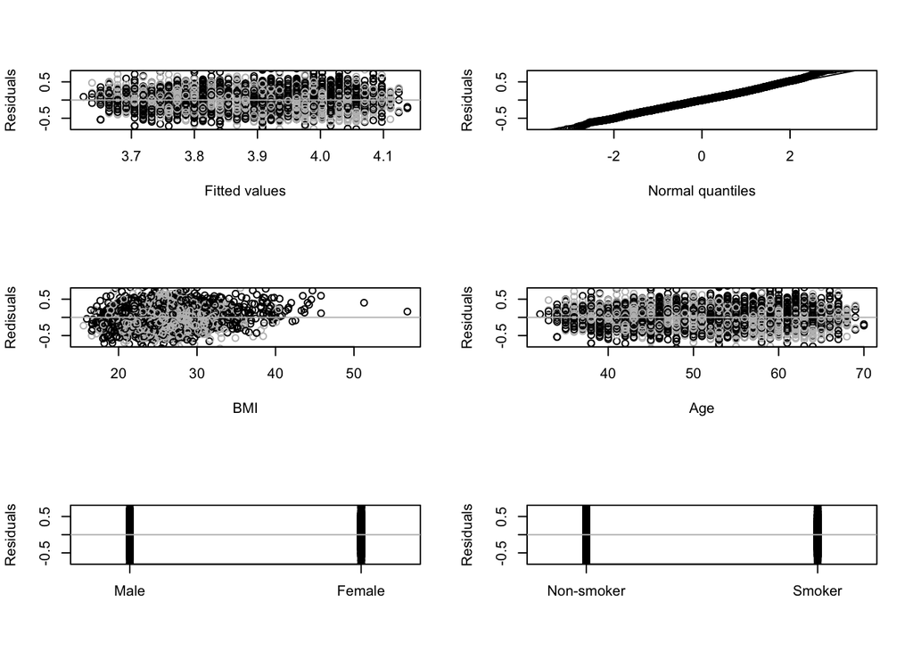

```r
our.residual.plots <- function( model,
                                ylim = c( -0.75, 0.75)){
      # cal. the residuals
      res <- resid( model )

      # cal. the fitted values
      fits <- fitted( model )

      # produce a plot which has 3 rows by 2 columns
      par( mfrow = c( 3, 2 ))

      # plot the residual versus the fitted values
      plot( fits,
            res,
            xlab = 'Fitted values',
            ylab = 'Residuals',
            ylim = ylim,
            col = ifelse( is.female == 1, 'black', 'grey' ))
      abline( h = 0, col = 'grey' )

      # produce a normal qq plot for the residuals
      qqnorm( res, main = '',
              xlab = 'Normal quantiles',
              ylab = 'Residuals',
              ylim = ylim )
      qqline( res )

      # plot the residuals versus the height
      plot( fhs$BMI,
            res,
            xlab = 'BMI',
            ylab = 'Redisuals',
            ylim = ylim,
            col = ifelse( is.female == 1, 'black', 'grey' ))
      abline( h = 0, col = 'grey' )

      # plot the residuals vs. the age
      plot( age, res,
            xlab = 'Age',
            ylab = 'Residuals',
            ylim = ylim,
            col = ifelse( is.female == 1, 'black', 'grey' ))
      abline( h = 0, col = 'grey' )

      # plot the residuals vs. the gender
      plot ( is.female, res,
             xlab = ' ',
             ylab = 'Residuals',
             ylim = ylim,
             xaxt = 'n',
             xlim = c( -0.2, 1.2 ))
      axis( side = 1, at = c( 0, 1 ), labels = c( 'Male', 'Female' ) )
      abline( h = 0, col = 'grey' )

      ## plot the residuals vs. the smoking status
      #
      plot ( is.smoker, res,
             xlab = '',
             ylab = 'Residuals',
             ylim = ylim,
             xaxt = 'n',
             xlim = c( -0.2, 1.2 ))
      axis( side = 1, at = c( 0, 1 ), labels = c( 'Non-smoker', 'Smoker' ) )
      abline( h = 0, col = 'grey' )
}

# produce the plot
our.residual.plots( age.model )
```

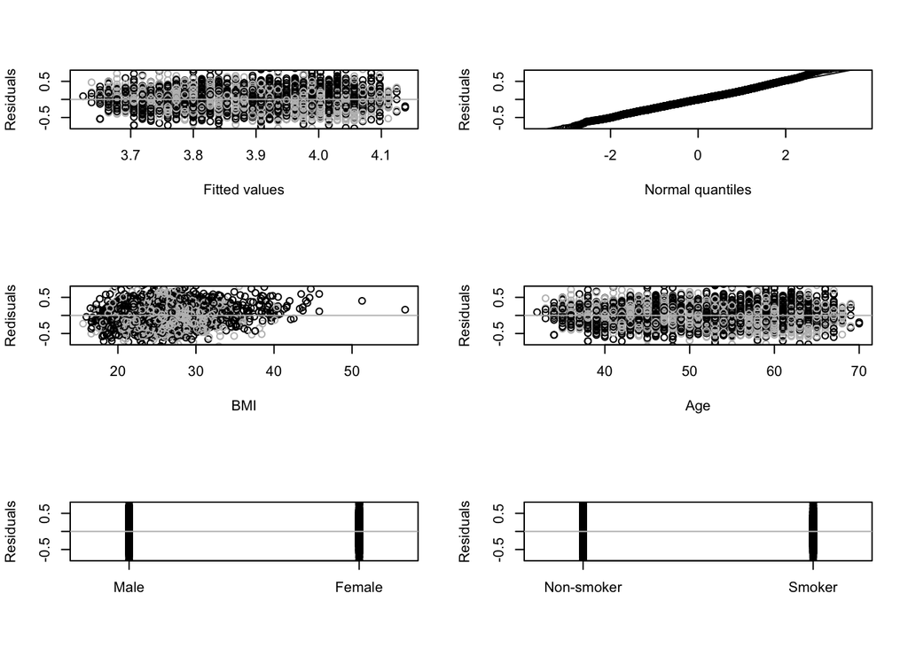

```r
# produce the plot
our.residual.plots( age.model )
```

## 2) gender

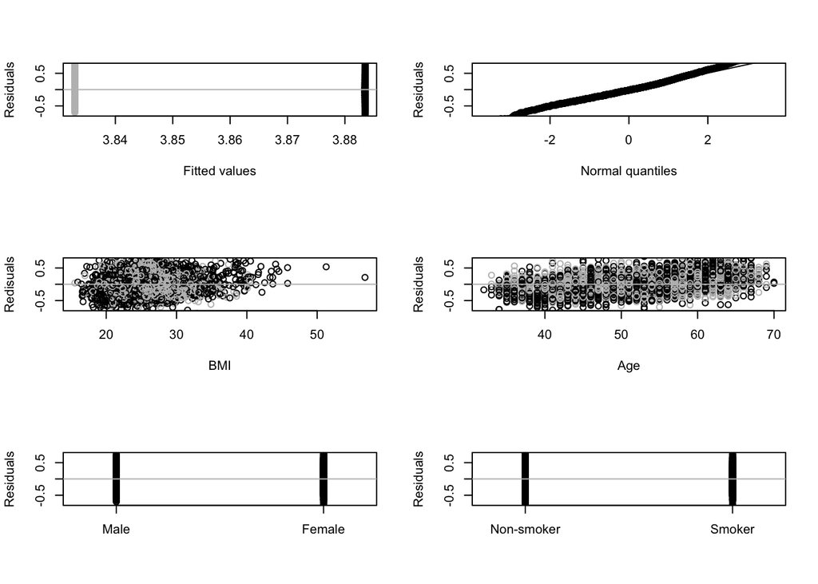

```r
# produce the plot
our.residual.plots( gender.model )
```

What do you like about the fit of model, and what do you not like?

## 3) bmi

```r
# produce the plot
#our.residual.plots( BMI.model )
```

# 2.3. What do add next?

```r
# age and gender
age.gender.model <- lm(log.bpd ~ age + is.female )
summary(age.gender.model)
```

```
##
## Call:
## lm(formula = log.bpd ~ age + is.female)
##
## Residuals:
##     Min      1Q  Median      3Q     Max
## -1.0302 -0.1654 -0.0038  0.1526  1.0283
##
## Coefficients:
##              Estimate Std. Error t value Pr(>|t|)
## (Intercept) 3.1698450  0.0227791 139.156  < 2e-16 ***
## age         0.0134520  0.0004467  30.117  < 2e-16 ***
## is.female   0.0438047  0.0077353   5.663 1.59e-08 ***
## ---
## Signif. codes:  0 '***' 0.001 '**' 0.01 '*' 0.05 '.' 0.1 ' ' 1
##
## Residual standard error: 0.2492 on 4237 degrees of freedom
## Multiple R-squared:  0.1831, Adjusted R-squared:  0.1827
## F-statistic: 474.9 on 2 and 4237 DF,  p-value: < 2.2e-16
```

```r
anova(age.gender.model)
```

```
## Analysis of Variance Table
##
## Response: log.bpd
##             Df  Sum Sq Mean Sq F value    Pr(>F)
## age          1  56.993  56.993 917.720 < 2.2e-16 ***
## is.female    1   1.992   1.992  32.069 1.586e-08 ***
## Residuals 4237 263.130   0.062
## ---
## Signif. codes:  0 '***' 0.001 '**' 0.01 '*' 0.05 '.' 0.1 ' ' 1
```

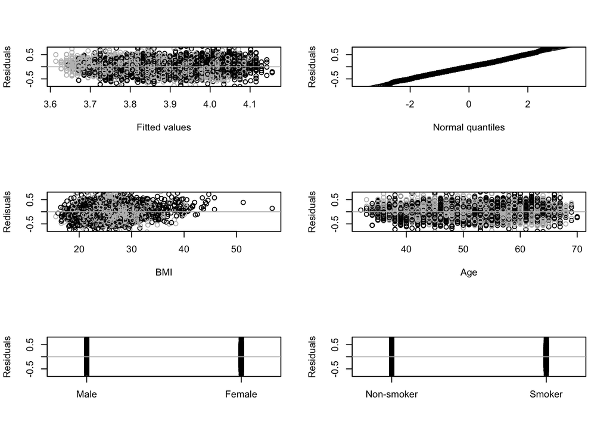

```r
our.residual.plots(age.gender.model)
```

```r
# add bmi to gender
bmi.gender.model <- lm(log.bpd ~ fhs$BMI + is.female )
summary(bmi.gender.model)
```

```
##
## Call:
## lm(formula = log.bpd ~ fhs$BMI + is.female)
##
## Residuals:
##      Min       1Q   Median       3Q      Max
## -1.13577 -0.17719 -0.01224  0.15771  1.02196
##
## Coefficients:
##             Estimate Std. Error t value Pr(>|t|)
## (Intercept) 3.498123   0.027400 127.670  < 2e-16 ***
## fhs$BMI     0.012776   0.001018  12.547  < 2e-16 ***
## is.female   0.059138   0.008390   7.049  2.1e-12 ***
## ---
## Signif. codes:  0 '***' 0.001 '**' 0.01 '*' 0.05 '.' 0.1 ' ' 1
##
## Residual standard error: 0.269 on 4218 degrees of freedom
##   (19 observations deleted due to missingness)
## Multiple R-squared:  0.04396,    Adjusted R-squared:  0.0435
## F-statistic: 96.96 on 2 and 4218 DF,  p-value: < 2.2e-16
```

```r
anova(bmi.gender.model)
```

```
## Analysis of Variance Table
##
## Response: log.bpd
##             Df  Sum Sq Mean Sq F value    Pr(>F)
## fhs$BMI      1  10.434 10.4343 144.245 < 2.2e-16 ***
## is.female    1   3.594  3.5939  49.682 2.103e-12 ***
## Residuals 4218 305.120  0.0723
## ---
## Signif. codes:  0 '***' 0.001 '**' 0.01 '*' 0.05 '.' 0.1 ' ' 1
```

```r
#our.residual.plots(bmi.gender.model)
```